# **"Predicting Profit Margins for Strategic Decision-Making in Retail: A Machine Learning Approach"**

by Hisham D Macaraya

Student ID: W215446864

## **Introduction**

In the highly competitive electronics retail market, Smart Electronics Store (SES) faces the challenge of maintaining robust growth and profitability while adapting to rapidly changing customer preferences and technology trends. With a diverse product range including smartphones, headphones, smartwatches, and gaming accessories, SES recognizes the need to leverage data-driven insights to enhance strategic decision-making.

This project focuses on predicting profit margins for SES’s product lines using machine learning techniques, specifically Lasso Regression and Support Vector Machines (SVM). By analyzing detailed sales data, the project aims to identify high-margin products, optimize pricing strategies, and streamline inventory management. Accurate profit margin predictions will empower SES to make informed decisions, such as prioritizing profitable products, tailoring promotional efforts, and negotiating better supplier terms.

Through this study, SES seeks to harness the power of predictive analytics to adapt to market dynamics, improve cost efficiency, and solidify its position as a leader in the electronics retail space. This project not only provides actionable insights for SES but also serves as a practical demonstration of applying machine learning in real-world business scenarios.

```python
# IMPORTANT: RUN THIS CELL IN ORDER TO IMPORT YOUR KAGGLE DATA SOURCES
# TO THE CORRECT LOCATION (/kaggle/input) IN YOUR NOTEBOOK,
# THEN FEEL FREE TO DELETE THIS CELL.
# NOTE: THIS NOTEBOOK ENVIRONMENT DIFFERS FROM KAGGLE'S PYTHON
# ENVIRONMENT SO THERE MAY BE MISSING LIBRARIES USED BY YOUR
# NOTEBOOK.

import os
import sys
from tempfile import NamedTemporaryFile
from urllib.request import urlopen
from urllib.parse import unquote, urlparse
from urllib.error import HTTPError
from zipfile import ZipFile
import tarfile
import shutil

CHUNK_SIZE = 40960
DATA_SOURCE_MAPPING = 'salesdata:https%3A%2F%2Fstorage.googleapis.com%2Fkaggle-data-sets%2F3697476%2F6525309%2Fbundle%2Farchive.zip%3FX-Goog-Algorithm%3DGOOG4-RSA-SHA256%26X-Goog-Credential%3Dgcp-kaggle-com%2540kaggle-161607.iam.gserviceaccount.com%252F20240425%252Fauto%252Fstorage%252Fgoog4_request%26X-Goog-Date%3D20240425T235901Z%26X-Goog-Expires%3D259200%26X-Goog-SignedHeaders%3Dhost%26X-Goog-Signature%3D5340b76871fa5f3ae371d37b43ddd594ed750603b654f052c1400562e5…'

KAGGLE_INPUT_PATH='/kaggle/input'
KAGGLE_WORKING_PATH='/kaggle/working'
KAGGLE_SYMLINK='kaggle'

!umount /kaggle/input/ 2> /dev/null
shutil.rmtree('/kaggle/input', ignore_errors=True)
os.makedirs(KAGGLE_INPUT_PATH, 0o777, exist_ok=True)
os.makedirs(KAGGLE_WORKING_PATH, 0o777, exist_ok=True)

try:
  os.symlink(KAGGLE_INPUT_PATH, os.path.join("..", 'input'), target_is_directory=True)
except FileExistsError:
  pass
try:
  os.symlink(KAGGLE_WORKING_PATH, os.path.join("..", 'working'), target_is_directory=True)
except FileExistsError:
  pass

for data_source_mapping in DATA_SOURCE_MAPPING.split(','):
    directory, download_url_encoded = data_source_mapping.split(':')
    download_url = unquote(download_url_encoded)
    filename = urlparse(download_url).path
    destination_path = os.path.join(KAGGLE_INPUT_PATH, directory)
    try:
        with urlopen(download_url) as fileres, NamedTemporaryFile() as tfile:
            total_length = fileres.headers['content-length']
            print(f'Downloading {directory}, {total_length} bytes compressed')
            dl = 0
            data = fileres.read(CHUNK_SIZE)
            while len(data) > 0:
                dl += len(data)
                tfile.write(data)
                done = int(50 * dl / int(total_length))
                sys.stdout.write(f"\r[{'=' * done}{' ' * (50-done)}] {dl} bytes downloaded")
                sys.stdout.flush()
                data = fileres.read(CHUNK_SIZE)
            if filename.endswith('.zip'):
              with ZipFile(tfile) as zfile:
                zfile.extractall(destination_path)
            else:
              with tarfile.open(tfile.name) as tarfile:
                tarfile.extractall(destination_path)
            print(f'\nDownloaded and uncompressed: {directory}')
    except HTTPError as e:
        print(f'Failed to load (likely expired) {download_url} to path {destination_path}')
        continue
    except OSError as e:
        print(f'Failed to load {download_url} to path {destination_path}')
        continue

print('Data source import complete.')
```

```
Downloading salesdata, 4795014 bytes compressed
[==================================================] 4795014 bytes downloaded
Downloaded and uncompressed: salesdata
Data source import complete.
```

## Data Loading and Exploration

In this section, we load the sales data from a CSV file and perform initial exploration to understand the structure and content of the dataset. We check for null values, data types, and perform feature engineering to prepare the data for analysis and modeling.

```python
# This Python 3 environment comes with many helpful analytics libraries installed
# It is defined by the kaggle/python Docker image: https://github.com/kaggle/docker-python
# For example, here's several helpful packages to load

import numpy as np # linear algebra
import pandas as pd # data processing, CSV file I/O (e.g. pd.read_csv
import matplotlib.pyplot as plt
import seaborn as sns

# Input data files are available in the read-only "../input/" directory
# For example, running this (by clicking run or pressing Shift+Enter) will list all files under the input directory

import os
for dirname, _, filenames in os.walk('/kaggle/input'):
    for filename in filenames:
        print(os.path.join(dirname, filename))

# You can write up to 20GB to the current directory (/kaggle/working/) that gets preserved as output when you create a version using "Save & Run All"
# You can also write temporary files to /kaggle/temp/, but they won't be saved outside of the current session
```

```
/kaggle/input/salesdata/sales_data.csv
```

```python
df = pd.read_csv('/kaggle/input/salesdata/sales_data.csv')
```

```python
df.head()
```

|  | Order Date | Order ID | Product | Product_ean | catégorie | Purchase Address | Quantity Ordered | Price Each | Cost price | turnover | margin |
| --- | --- | --- | --- | --- | --- | --- | --- | --- | --- | --- | --- |
| 0 | 2019-01-22 21:25:00 | 141234 | iPhone | 5.638009e+12 | Vêtements | 944 Walnut St, Boston, MA 02215 | 1 | 700.00 | 231.0000 | 700.00 | 469.0000 |
| 1 | 2019-01-28 14:15:00 | 141235 | Lightning Charging Cable | 5.563320e+12 | Alimentation | 185 Maple St, Portland, OR 97035 | 1 | 14.95 | 7.4750 | 14.95 | 7.4750 |
| 2 | 2019-01-17 13:33:00 | 141236 | Wired Headphones | 2.113973e+12 | Vêtements | 538 Adams St, San Francisco, CA 94016 | 2 | 11.99 | 5.9950 | 23.98 | 11.9900 |
| 3 | 2019-01-05 20:33:00 | 141237 | 27in FHD Monitor | 3.069157e+12 | Sports | 738 10th St, Los Angeles, CA 90001 | 1 | 149.99 | 97.4935 | 149.99 | 52.4965 |
| 4 | 2019-01-25 11:59:00 | 141238 | Wired Headphones | 9.692681e+12 | Électronique | 387 10th St, Austin, TX 73301 | 1 | 11.99 | 5.9950 | 11.99 | 5.9950 |

### Handling Null Values

To handle null values in the dataset, we first check for the presence of null values using the `isnull().sum()` method. If null values are found, we can decide on an appropriate strategy to handle them, such as removing rows with null values or imputing them with mean, median, or mode.

In this project, we will use the following steps to handle null values:

1. Identify columns with null values.
2. Decide on an imputation strategy based on the nature of the data.
3. Apply the imputation strategy to fill or remove null values.

The code to check for null values is as follows:

```python
df.isnull().sum()
```

```
Order Date          0
Order ID            0
Product             0
Product_ean         0
catégorie           0
Purchase Address    0
Quantity Ordered    0
Price Each          0
Cost price          0
turnover            0
margin              0
dtype: int64
```

```python
#check data types of each feature and also check null values
df.info()
```

```
<class 'pandas.core.frame.DataFrame'>
RangeIndex: 185950 entries, 0 to 185949
Data columns (total 11 columns):
 #   Column            Non-Null Count   Dtype
---  ------            --------------   -----
 0   Order Date        185950 non-null  object
 1   Order ID          185950 non-null  int64
 2   Product           185950 non-null  object
 3   Product_ean       185950 non-null  float64
 4   catégorie         185950 non-null  object
 5   Purchase Address  185950 non-null  object
 6   Quantity Ordered  185950 non-null  int64
 7   Price Each        185950 non-null  float64
 8   Cost price        185950 non-null  float64
 9   turnover          185950 non-null  float64
 10  margin            185950 non-null  float64
dtypes: float64(5), int64(2), object(4)
memory usage: 15.6+ MB
```

## Feature Engineering

```python
#we split our date feature to month and year
df['Order Date'].head(1)
```

```
0    2019-01-22 21:25:00
Name: Order Date, dtype: object
```

```python
df['Order Year']=df['Order Date'].str.split(' ').str[0].str.split('-').str[0]
```

```python
df['Order Month']=df['Order Date'].str.split(' ').str[0].str.split('-').str[1]
```

```python
#we  need only cities not all address
df['Purchase City']=df['Purchase Address'].str.split(',').str[1]
```

```python
df['Purchase City'].value_counts()
```

```
Purchase City
 San Francisco    44732
 Los Angeles      29605
 New York City    24876
 Boston           19934
 Atlanta          14881
 Dallas           14820
 Seattle          14732
 Portland         12465
 Austin            9905
Name: count, dtype: int64
```

```python
#drop
df.drop(columns={'Order Date','Order ID','Product_ean','Purchase Address'},axis=1,inplace=True)
```

```python
#Handle Number of Unique values
```

```python
#there are many unique values we need to minimize this to smaller unique walues
df['Product'].value_counts()
```

```
Product
USB-C Charging Cable          21903
Lightning Charging Cable      21658
AAA Batteries (4-pack)        20641
AA Batteries (4-pack)         20577
Wired Headphones              18882
Apple Airpods Headphones      15549
Bose SoundSport Headphones    13325
27in FHD Monitor               7507
iPhone                         6842
27in 4K Gaming Monitor         6230
34in Ultrawide Monitor         6181
Google Phone                   5525
Flatscreen TV                  4800
Macbook Pro Laptop             4724
ThinkPad Laptop                4128
20in Monitor                   4101
Vareebadd Phone                2065
LG Washing Machine              666
LG Dryer                        646
Name: count, dtype: int64
```

```python
#we make a def funtion to minimize our unique values to lower
def change(x):
    if x in ['USB-C Charging Cable','Lightning Charging Cable']:
        return 'Charging Cables'
    elif x in ['AAA Batteries (4-pack)','AA Batteries (4-pack)']:
        return 'Batteries'
    elif x in ['Wired Headphones','Apple Airpods Headphones','Bose SoundSport Headphones']:
        return 'Headphones'
    elif x in ['27in FHD Monitor','27in 4K Gaming Monitor','34in Ultrawide Monitor','Flatscreen TV','20in Monitor']:
        return 'Smart Tv'
    elif x in ['iPhone','Google Phone','Vareebadd Phone']:
        return 'Smart Phones'
    elif x in ['Macbook Pro Laptop','ThinkPad Laptop']:
        return 'Laptops'
    elif x in ['LG Washing Machine','LG Dryer']:
        return 'Cleaning Machines'
    else:
        return 'Others'
```

```python
df['Product'] = df['Product'].apply(change)
```

```python
df['Product'].value_counts()
```

```
Product
Headphones           47756
Charging Cables      43561
Batteries            41218
Smart Tv             28819
Smart Phones         14432
Laptops               8852
Cleaning Machines     1312
Name: count, dtype: int64
```

```python
df.head(1)
```

|  | Product | catégorie | Quantity Ordered | Price Each | Cost price | turnover | margin | Order Year | Order Month | Purchase City |
| --- | --- | --- | --- | --- | --- | --- | --- | --- | --- | --- |
| 0 | Smart Phones | Vêtements | 1 | 700.0 | 231.0 | 700.0 | 469.0 | 2019 | 01 | Boston |

```python
#convert french language faeature to english for better understanding
df.rename(columns={'catégorie':'Category'},inplace=True)
```

```python
df['Category'].value_counts()
```

```
Category
Sports          46925
Vêtements       46405
Alimentation    46342
Électronique    46278
Name: count, dtype: int64
```

```python
#same as change fature data french to english for better understanding
data_mapping = {
    'Vêtements': 'Clothes',
    'Électronique': 'Electronics'
}
df['Category'] = df['Category'].map(data_mapping).fillna(df['Category'])
```

```python
df['Category'].value_counts()
```

```
Category
Sports          46925
Clothes         46405
Alimentation    46342
Electronics     46278
Name: count, dtype: int64
```

```python
#check data types of each feature
df.info()
```

```
<class 'pandas.core.frame.DataFrame'>
RangeIndex: 185950 entries, 0 to 185949
Data columns (total 10 columns):
 #   Column            Non-Null Count   Dtype
---  ------            --------------   -----
 0   Product           185950 non-null  object
 1   Category          185950 non-null  object
 2   Quantity Ordered  185950 non-null  int64
 3   Price Each        185950 non-null  float64
 4   Cost price        185950 non-null  float64
 5   turnover          185950 non-null  float64
 6   margin            185950 non-null  float64
 7   Order Year        185950 non-null  object
 8   Order Month       185950 non-null  object
 9   Purchase City     185950 non-null  object
dtypes: float64(4), int64(1), object(5)
memory usage: 14.2+ MB
```

```python
#convert float data to int for minimize our data to low
df['Order Month'] = df['Order Month'].astype(int)
df['Order Year'] = df['Order Year'].astype(int)
```

```python
df.info()
```

```
<class 'pandas.core.frame.DataFrame'>
RangeIndex: 185950 entries, 0 to 185949
Data columns (total 10 columns):
 #   Column            Non-Null Count   Dtype
---  ------            --------------   -----
 0   Product           185950 non-null  object
 1   Category          185950 non-null  object
 2   Quantity Ordered  185950 non-null  int64
 3   Price Each        185950 non-null  float64
 4   Cost price        185950 non-null  float64
 5   turnover          185950 non-null  float64
 6   margin            185950 non-null  float64
 7   Order Year        185950 non-null  int64
 8   Order Month       185950 non-null  int64
 9   Purchase City     185950 non-null  object
dtypes: float64(4), int64(3), object(3)
memory usage: 14.2+ MB
```

```python
df.head()
```

|  | Product | Category | Quantity Ordered | Price Each | Cost price | turnover | margin | Order Year | Order Month | Purchase City |
| --- | --- | --- | --- | --- | --- | --- | --- | --- | --- | --- |
| 0 | Smart Phones | Clothes | 1 | 700.00 | 231.0000 | 700.00 | 469.0000 | 2019 | 1 | Boston |
| 1 | Charging Cables | Alimentation | 1 | 14.95 | 7.4750 | 14.95 | 7.4750 | 2019 | 1 | Portland |
| 2 | Headphones | Clothes | 2 | 11.99 | 5.9950 | 23.98 | 11.9900 | 2019 | 1 | San Francisco |
| 3 | Smart Tv | Sports | 1 | 149.99 | 97.4935 | 149.99 | 52.4965 | 2019 | 1 | Los Angeles |
| 4 | Headphones | Electronics | 1 | 11.99 | 5.9950 | 11.99 | 5.9950 | 2019 | 1 | Austin |

```python
#Exploratary Data Analysis
```

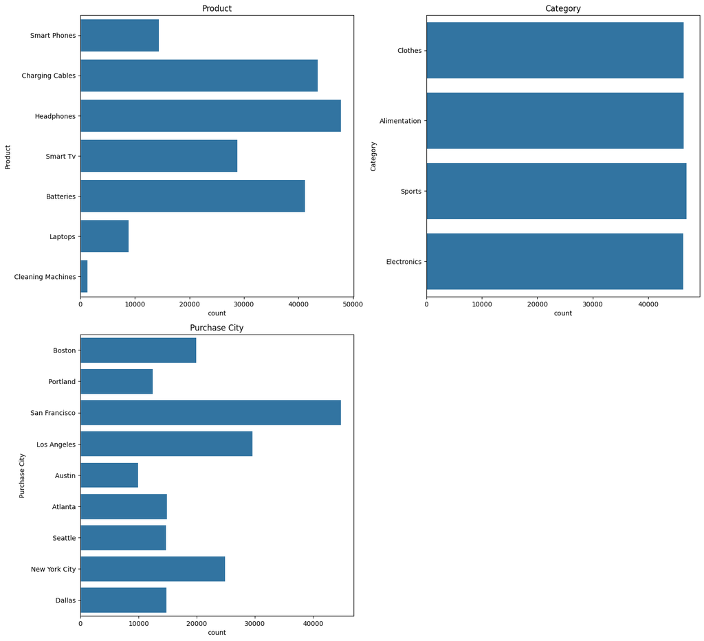

```python
#exploratary data analysis on category features
cat = df.select_dtypes(include='object').columns.tolist()
col = len(cat)

fig , axs = plt.subplots(nrows=col,ncols=2,figsize=(15,20))
axs = axs.flatten()

for i , var in enumerate (cat):
    sns.countplot(y=var,data=df,ax=axs[i])
    axs[i].set_title(var)

if col < len(axs):
    for i in range(col, len(axs)):
        fig.delaxes(axs[i])

fig.tight_layout()
plt.show()
```

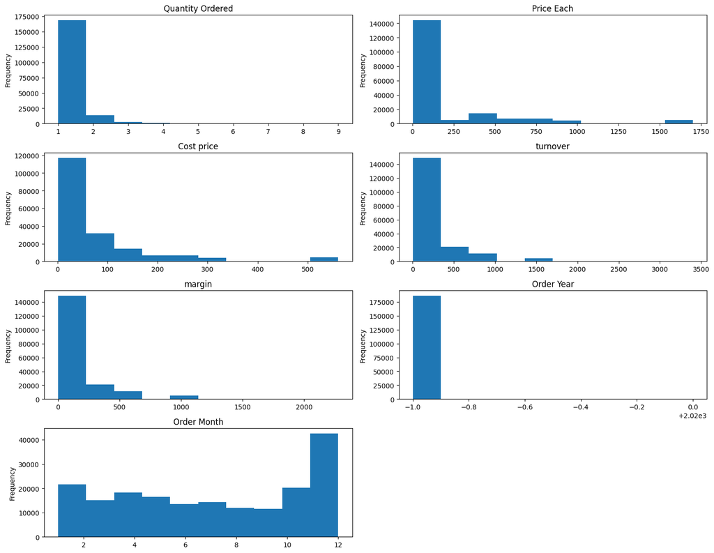

```python
#exploratary data analysis on numerical or continuous features
num = df.select_dtypes(include=['int','float']).columns.tolist()
col = len(num)

fig , axs = plt.subplots(nrows=col,ncols=2,figsize=(15,20))
axs = axs.flatten()

for i , var in enumerate (num):
    df[var].plot.hist(ax=axs[i])
    axs[i].set_title(var)

if col < len(axs):
    for i in range(col, len(axs)):
        fig.delaxes(axs[i])

fig.tight_layout()
plt.show()
```

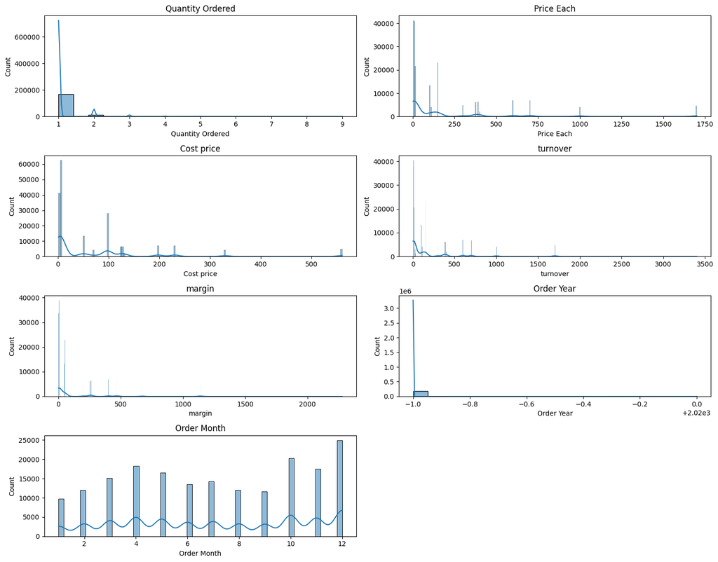

```python
#exploratary data anaylsis with kde(kernal density estimation)
num = df.select_dtypes(include=['int','float']).columns.tolist()
col = len(num)

fig , axs = plt.subplots(nrows=col,ncols=2,figsize=(15,20))
axs = axs.flatten()

for i , var in enumerate (num):
    sns.histplot(data=df,x=var,kde=True,ax=axs[i])
    axs[i].set_title(var)

if col < len(axs):
    for i in range(col, len(axs)):
        fig.delaxes(axs[i])

fig.tight_layout()
plt.show()
```

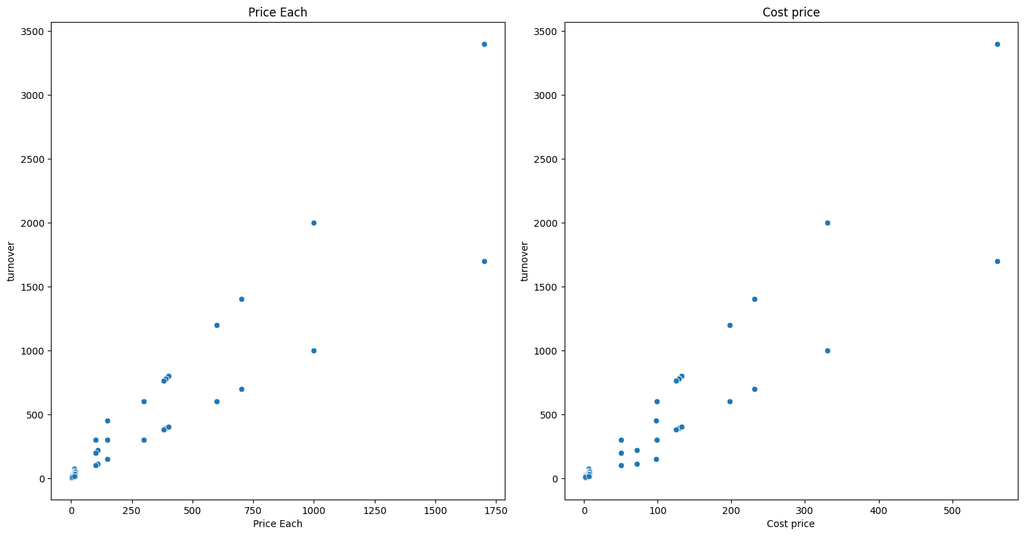

```python
#using scatter plot to tells relation between 2 independent feature
num = ['Price Each','Cost price']
col = len(num)

fig , axs = plt.subplots(nrows=col,ncols=2,figsize=(15,15))
axs = axs.flatten()

for i , var in enumerate (num):
    sns.scatterplot(x=var,y='turnover',data=df,ax=axs[i])
    axs[i].set_title(var)

if col < len(axs):
    for i in range(col, len(axs)):
        fig.delaxes(axs[i])

fig.tight_layout()
plt.show()
```

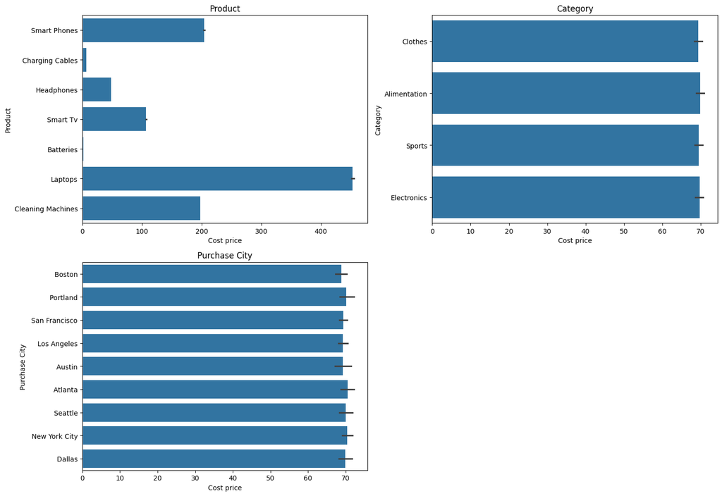

```python
#eda using dependent feature cost price
cat = ['Product','Category','Purchase City']
col = len(cat)
fig, axs = plt.subplots(nrows=col,ncols=2,figsize=(15,15))
axs = axs.flatten()

for i, var in enumerate (cat):
    sns.barplot(x='Cost price', y=var, data=df, ax=axs[i])
    axs[i].set_title(var)

if col < len(axs):
    for i in range(col, len(axs)):
        fig.delaxes(axs[i])

fig.tight_layout()
plt.show()
```

Building the ML Model

```python
df.head()
```

|  | Product | Category | Quantity Ordered | Price Each | Cost price | turnover | margin | Order Year | Order Month | Purchase City |
| --- | --- | --- | --- | --- | --- | --- | --- | --- | --- | --- |
| 0 | Smart Phones | Clothes | 1 | 700.00 | 231.0000 | 700.00 | 469.0000 | 2019 | 1 | Boston |
| 1 | Charging Cables | Alimentation | 1 | 14.95 | 7.4750 | 14.95 | 7.4750 | 2019 | 1 | Portland |
| 2 | Headphones | Clothes | 2 | 11.99 | 5.9950 | 23.98 | 11.9900 | 2019 | 1 | San Francisco |
| 3 | Smart Tv | Sports | 1 | 149.99 | 97.4935 | 149.99 | 52.4965 | 2019 | 1 | Los Angeles |
| 4 | Headphones | Electronics | 1 | 11.99 | 5.9950 | 11.99 | 5.9950 | 2019 | 1 | Austin |

```python
df= df.drop('Category',axis=1)
df.head()
```

|  | Product | Quantity Ordered | Price Each | Cost price | turnover | margin | Order Year | Order Month | Purchase City |
| --- | --- | --- | --- | --- | --- | --- | --- | --- | --- |
| 0 | Smart Phones | 1 | 700.00 | 231.0000 | 700.00 | 469.0000 | 2019 | 1 | Boston |
| 1 | Charging Cables | 1 | 14.95 | 7.4750 | 14.95 | 7.4750 | 2019 | 1 | Portland |
| 2 | Headphones | 2 | 11.99 | 5.9950 | 23.98 | 11.9900 | 2019 | 1 | San Francisco |
| 3 | Smart Tv | 1 | 149.99 | 97.4935 | 149.99 | 52.4965 | 2019 | 1 | Los Angeles |
| 4 | Headphones | 1 | 11.99 | 5.9950 | 11.99 | 5.9950 | 2019 | 1 | Austin |

```python
df.info()
```

```
<class 'pandas.core.frame.DataFrame'>
RangeIndex: 185950 entries, 0 to 185949
Data columns (total 9 columns):
 #   Column            Non-Null Count   Dtype
---  ------            --------------   -----
 0   Product           185950 non-null  object
 1   Quantity Ordered  185950 non-null  int64
 2   Price Each        185950 non-null  float64
 3   Cost price        185950 non-null  float64
 4   turnover          185950 non-null  float64
 5   margin            185950 non-null  float64
 6   Order Year        185950 non-null  int64
 7   Order Month       185950 non-null  int64
 8   Purchase City     185950 non-null  object
dtypes: float64(4), int64(3), object(2)
memory usage: 12.8+ MB
```

```python
df['Product'].value_counts()
```

```
Product
Headphones           47756
Charging Cables      43561
Batteries            41218
Smart Tv             28819
Smart Phones         14432
Laptops               8852
Cleaning Machines     1312
Name: count, dtype: int64
```

```python
#Getting Dummy Variables(One-hot-encoding)
df=pd.get_dummies(data=df,drop_first=True)
df.head()
```

|  | Quantity Ordered | Price Each | Cost price | turnover | margin | Order Year | Order Month | Product_Charging Cables | Product_Cleaning Machines | Product_Headphones | ... | Product_Smart Phones | Product_Smart Tv | Purchase City_ Austin | Purchase City_ Boston | Purchase City_ Dallas | Purchase City_ Los Angeles | Purchase City_ New York City | Purchase City_ Portland | Purchase City_ San Francisco | Purchase City_ Seattle |
| --- | --- | --- | --- | --- | --- | --- | --- | --- | --- | --- | --- | --- | --- | --- | --- | --- | --- | --- | --- | --- | --- |
| 0 | 1 | 700.00 | 231.0000 | 700.00 | 469.0000 | 2019 | 1 | False | False | False | ... | True | False | False | True | False | False | False | False | False | False |
| 1 | 1 | 14.95 | 7.4750 | 14.95 | 7.4750 | 2019 | 1 | True | False | False | ... | False | False | False | False | False | False | False | True | False | False |
| 2 | 2 | 11.99 | 5.9950 | 23.98 | 11.9900 | 2019 | 1 | False | False | True | ... | False | False | False | False | False | False | False | False | True | False |
| 3 | 1 | 149.99 | 97.4935 | 149.99 | 52.4965 | 2019 | 1 | False | False | False | ... | False | True | False | False | False | True | False | False | False | False |
| 4 | 1 | 11.99 | 5.9950 | 11.99 | 5.9950 | 2019 | 1 | False | False | True | ... | False | False | True | False | False | False | False | False | False | False |

5 rows × 21 columns

```python
y=df['margin']
X=df.drop('margin',axis=1)
X.head()
```

|  | Quantity Ordered | Price Each | Cost price | turnover | Order Year | Order Month | Product_Charging Cables | Product_Cleaning Machines | Product_Headphones | Product_Laptops | Product_Smart Phones | Product_Smart Tv | Purchase City_ Austin | Purchase City_ Boston | Purchase City_ Dallas | Purchase City_ Los Angeles | Purchase City_ New York City | Purchase City_ Portland | Purchase City_ San Francisco | Purchase City_ Seattle |
| --- | --- | --- | --- | --- | --- | --- | --- | --- | --- | --- | --- | --- | --- | --- | --- | --- | --- | --- | --- | --- |
| 0 | 1 | 700.00 | 231.0000 | 700.00 | 2019 | 1 | False | False | False | False | True | False | False | True | False | False | False | False | False | False |
| 1 | 1 | 14.95 | 7.4750 | 14.95 | 2019 | 1 | True | False | False | False | False | False | False | False | False | False | False | True | False | False |
| 2 | 2 | 11.99 | 5.9950 | 23.98 | 2019 | 1 | False | False | True | False | False | False | False | False | False | False | False | False | True | False |
| 3 | 1 | 149.99 | 97.4935 | 149.99 | 2019 | 1 | False | False | False | False | False | True | False | False | False | True | False | False | False | False |
| 4 | 1 | 11.99 | 5.9950 | 11.99 | 2019 | 1 | False | False | True | False | False | False | True | False | False | False | False | False | False | False |

```python
X.info()
```

```
<class 'pandas.core.frame.DataFrame'>
RangeIndex: 185950 entries, 0 to 185949
Data columns (total 20 columns):
 #   Column                        Non-Null Count   Dtype
---  ------                        --------------   -----
 0   Quantity Ordered              185950 non-null  int64
 1   Price Each                    185950 non-null  float64
 2   Cost price                    185950 non-null  float64
 3   turnover                      185950 non-null  float64
 4   Order Year                    185950 non-null  int64
 5   Order Month                   185950 non-null  int64
 6   Product_Charging Cables       185950 non-null  bool
 7   Product_Cleaning Machines     185950 non-null  bool
 8   Product_Headphones            185950 non-null  bool
 9   Product_Laptops               185950 non-null  bool
 10  Product_Smart Phones          185950 non-null  bool
 11  Product_Smart Tv              185950 non-null  bool
 12  Purchase City_ Austin         185950 non-null  bool
 13  Purchase City_ Boston         185950 non-null  bool
 14  Purchase City_ Dallas         185950 non-null  bool
 15  Purchase City_ Los Angeles    185950 non-null  bool
 16  Purchase City_ New York City  185950 non-null  bool
 17  Purchase City_ Portland       185950 non-null  bool
 18  Purchase City_ San Francisco  185950 non-null  bool
 19  Purchase City_ Seattle        185950 non-null  bool
dtypes: bool(14), float64(3), int64(3)
memory usage: 11.0 MB
```

```python
from sklearn.model_selection import train_test_split
X_train,X_test,y_train,y_test=train_test_split(X,y,test_size=0.2,random_state=42)
X_train
```

|  | Quantity Ordered | Price Each | Cost price | turnover | Order Year | Order Month | Product_Charging Cables | Product_Cleaning Machines | Product_Headphones | Product_Laptops | Product_Smart Phones | Product_Smart Tv | Purchase City_ Austin | Purchase City_ Boston | Purchase City_ Dallas | Purchase City_ Los Angeles | Purchase City_ New York City | Purchase City_ Portland | Purchase City_ San Francisco | Purchase City_ Seattle |
| --- | --- | --- | --- | --- | --- | --- | --- | --- | --- | --- | --- | --- | --- | --- | --- | --- | --- | --- | --- | --- |
| 142210 | 1 | 11.99 | 5.9950 | 11.99 | 2019 | 10 | False | False | True | False | False | False | False | False | False | False | False | False | True | False |
| 172951 | 1 | 11.99 | 5.9950 | 11.99 | 2019 | 12 | False | False | True | False | False | False | False | False | False | False | False | False | False | False |
| 147105 | 1 | 149.99 | 97.4935 | 149.99 | 2019 | 11 | False | False | False | False | False | True | False | False | False | False | True | False | False | False |
| 124056 | 1 | 389.99 | 128.6967 | 389.99 | 2019 | 10 | False | False | False | False | False | True | False | False | False | False | False | False | True | False |
| 22827 | 1 | 11.99 | 5.9950 | 11.99 | 2019 | 3 | False | False | True | False | False | False | True | False | False | False | False | False | False | False |
| ... | ... | ... | ... | ... | ... | ... | ... | ... | ... | ... | ... | ... | ... | ... | ... | ... | ... | ... | ... | ... |
| 119879 | 4 | 2.99 | 1.4950 | 11.96 | 2019 | 9 | False | False | False | False | False | False | False | False | False | False | True | False | False | False |
| 103694 | 1 | 150.00 | 97.5000 | 150.00 | 2019 | 8 | False | False | True | False | False | False | False | False | False | False | False | False | True | False |
| 131932 | 1 | 11.99 | 5.9950 | 11.99 | 2019 | 10 | False | False | True | False | False | False | False | False | False | True | False | False | False | False |
| 146867 | 1 | 2.99 | 1.4950 | 2.99 | 2019 | 11 | False | False | False | False | False | False | False | False | False | False | False | True | False | False |
| 121958 | 2 | 2.99 | 1.4950 | 5.98 | 2019 | 9 | False | False | False | False | False | False | False | False | False | False | False | False | False | True |

148760 rows × 20 columns

Linear Regression

```python
from sklearn.linear_model import LinearRegression
reg = LinearRegression().fit(X_train, y_train)
```

```python
print(reg.score(X_test,y_test))
```

```
0.9999629024831777
```

```python
X_test
```

|  | Quantity Ordered | Price Each | Cost price | turnover | Order Year | Order Month | Product_Charging Cables | Product_Cleaning Machines | Product_Headphones | Product_Laptops | Product_Smart Phones | Product_Smart Tv | Purchase City_ Austin | Purchase City_ Boston | Purchase City_ Dallas | Purchase City_ Los Angeles | Purchase City_ New York City | Purchase City_ Portland | Purchase City_ San Francisco | Purchase City_ Seattle |
| --- | --- | --- | --- | --- | --- | --- | --- | --- | --- | --- | --- | --- | --- | --- | --- | --- | --- | --- | --- | --- |
| 75632 | 1 | 99.99 | 49.9950 | 99.99 | 2019 | 6 | False | False | True | False | False | False | False | False | False | False | False | False | True | False |
| 30255 | 1 | 11.99 | 5.9950 | 11.99 | 2019 | 3 | False | False | True | False | False | False | False | False | False | False | False | False | False | False |
| 86718 | 1 | 11.99 | 5.9950 | 11.99 | 2019 | 7 | False | False | True | False | False | False | False | True | False | False | False | False | False | False |
| 167590 | 1 | 389.99 | 128.6967 | 389.99 | 2019 | 12 | False | False | False | False | False | True | False | False | False | False | True | False | False | False |
| 41197 | 1 | 700.00 | 231.0000 | 700.00 | 2019 | 4 | False | False | False | False | True | False | False | False | False | False | False | False | True | False |
| ... | ... | ... | ... | ... | ... | ... | ... | ... | ... | ... | ... | ... | ... | ... | ... | ... | ... | ... | ... | ... |
| 180101 | 1 | 150.00 | 97.5000 | 150.00 | 2019 | 12 | False | False | True | False | False | False | False | False | False | False | False | False | False | False |
| 93903 | 1 | 150.00 | 97.5000 | 150.00 | 2019 | 7 | False | False | True | False | False | False | False | False | False | True | False | False | False | False |
| 68931 | 1 | 3.84 | 1.9200 | 3.84 | 2019 | 5 | False | False | False | False | False | False | False | False | False | False | False | True | False | False |
| 99168 | 1 | 999.99 | 329.9967 | 999.99 | 2019 | 7 | False | False | False | True | False | False | False | False | False | False | False | False | True | False |
| 107380 | 1 | 3.84 | 1.9200 | 3.84 | 2019 | 8 | False | False | False | False | False | False | False | False | False | False | False | False | False | True |

37190 rows × 20 columns

```python
y_test
```

```
75632      49.9950
30255       5.9950
86718       5.9950
167590    261.2933
41197     469.0000
            ...
180101     52.5000
93903      52.5000
68931       1.9200
99168     669.9933
107380      1.9200
Name: margin, Length: 37190, dtype: float64
```

## Lasso Regression and Support Vector Machine (SVM)

Lasso Regression and Support Vector Machine (SVM) are two powerful machine learning techniques used for regression and classification tasks.

### Lasso Regression

Lasso Regression, or Least Absolute Shrinkage and Selection Operator, is a type of linear regression that uses shrinkage. Shrinkage is where data values are shrunk towards a central point, like the mean. The lasso procedure encourages simple, sparse models (i.e., models with fewer parameters). This particular type of regression is well-suited for models showing high levels of multicollinearity or when you need to automate certain parts of model selection, like variable selection/parameter elimination.

### Support Vector Machine (SVM)

Support Vector Machine (SVM) is a supervised machine learning algorithm that can be used for both classification or regression challenges. However, it is mostly used in classification problems. In this algorithm, we plot each data item as a point in n-dimensional space (where n is the number of features you have) with the value of each feature being the value of a particular coordinate. Then, we perform classification by finding the hyper-plane that differentiates the two classes very well.

### Import the require libraries

```python
# Import required libraries
import numpy as np
import pandas as pd
from sklearn.model_selection import train_test_split, GridSearchCV
from sklearn.preprocessing import LabelEncoder, StandardScaler
from sklearn.linear_model import LassoCV
from sklearn.svm import SVR
from sklearn.metrics import mean_squared_error, r2_score
```

### Load and Preprocess the Dataset

#### Double-check the dataset preprocessing:

1. **Handle Missing Values**:
   - Identify and handle any missing values in the dataset. This can be done by removing rows with missing values or imputing them with appropriate values (mean, median, mode, etc.).
2. **Encode Categorical Variables**:
   - Convert categorical variables into numerical values using techniques such as one-hot encoding or label encoding. This step is crucial for machine learning algorithms to process categorical data.
3. **Scale Numerical Features**:
   - Normalize or standardize numerical features to ensure that they are on a similar scale. This helps improve the performance of machine learning algorithms, especially those that rely on distance metrics.

```python
# Load the updated dataset
df = pd.read_csv('sales_data.csv')  # Ensure the updated CSV is in the correct path

# Convert 'Order Date' to datetime if necessary
df['Order Date'] = pd.to_datetime(df['Order Date'], errors='coerce')

# Calculate the profit margin if not already done
df['margin'] = ((df['Price Each'] - df['Cost price']) / df['Price Each']) * 100

# Drop unnecessary columns
df = df.drop(['Order ID', 'Purchase Address', 'Order Date', 'turnover'], axis=1, errors='ignore')

# Handle missing values
df = df.dropna()

# Encode categorical variables
le = LabelEncoder()
categorical_columns = ['Product', 'Product_ean', 'catégorie']
for col in categorical_columns:
    if df[col].dtype == 'object':
        df[col] = le.fit_transform(df[col])

# Features and target variable
X = df.drop('margin', axis=1)
y = df['margin']

# Feature scaling
scaler = StandardScaler()
X_scaled = scaler.fit_transform(X)
```

### Explanation:

1. **Load the Dataset**:
   - Loading the updated `sales_data.csv` file into a DataFrame.
2. **Convert 'Order Date'**:
   - Converting 'Order Date' to datetime format using `pd.to_datetime` with `errors='coerce'` to handle invalid dates.
3. **Calculate Margin**:
   - Computing the profit margin as `((Price Each - Cost price) / Price Each) * 100` if it isn't already present in the dataset.
4. **Drop Unnecessary Columns**:
   - Removing columns such as 'Order ID', 'Purchase Address', 'Order Date', and 'turnover' that are not needed for modeling.
5. **Handle Missing Values**:
   - Dropping rows with missing values using `df.dropna()`.
6. **Encode Categorical Variables**:
   - Using `LabelEncoder` to convert categorical features ('Product', 'Product_ean', 'catégorie') into numerical values.
7. **Feature Scaling**:
   - Standardizing numerical features using `StandardScaler` to ensure they are on a similar scale for better model performance.

```python
df.head() # Display the first few rows of the DataFrame
```

|  | Product | Product_ean | catégorie | Quantity Ordered | Price Each | Cost price | margin |
| --- | --- | --- | --- | --- | --- | --- | --- |
| 0 | 18 | 5.638009e+12 | 2 | 1 | 700.00 | 231.0000 | 67.0 |
| 1 | 12 | 5.563320e+12 | 0 | 1 | 14.95 | 7.4750 | 50.0 |
| 2 | 17 | 2.113973e+12 | 2 | 2 | 11.99 | 5.9950 | 50.0 |
| 3 | 2 | 3.069157e+12 | 1 | 1 | 149.99 | 97.4935 | 35.0 |
| 4 | 17 | 9.692681e+12 | 3 | 1 | 11.99 | 5.9950 | 50.0 |

### Split the Data into Training and Testing Sets

To build and evaluate our machine learning models, we need to split the dataset into training and testing sets. This allows us to train the model on one portion of the data and test its performance on another, unseen portion. This helps in assessing the model's ability to generalize to new data.

We will use the `train_test_split` function from `sklearn.model_selection` to split the data. The `test_size` parameter determines the proportion of the dataset to include in the test split, and the `random_state` parameter ensures reproducibility of the results.

Here's the code to split the data:

```python
# Split data into training and testing sets
X_train, X_test, y_train, y_test = train_test_split(
    X_scaled, y, test_size=0.2, random_state=42)
```

### Integrate Lasso Regression Model

```python
# Lasso Regression: Feature Selection and Regularization
lasso = LassoCV(cv=5, random_state=0)
lasso.fit(X_train, y_train)

# Evaluate Lasso Regression
y_pred_lasso = lasso.predict(X_test)
print("Lasso Regression Results:")
print(f"RMSE: {np.sqrt(mean_squared_error(y_test, y_pred_lasso)):.2f}")
print(f"R² Score: {r2_score(y_test, y_pred_lasso):.2f}")
```

```
Lasso Regression Results:
RMSE: 3.89
R² Score: 0.84
```

We begin by initializing and fitting the Lasso Regression model using `LassoCV`, which is a Lasso linear model that automatically tunes the regularization parameter using cross-validation. The `LassoCV` method performs Lasso regression with built-in cross-validation to find the optimal value of alpha (regularization strength) that minimizes prediction error. This is particularly useful for feature selection and preventing overfitting.

By fitting the model to the training data (`X_train`, `y_train`), the Lasso regression selects the most significant features by shrinking the less important feature coefficients to zero. This results in a simpler and more interpretable model. The cross-validation (`cv=5`) ensures that the model generalizes well to unseen data by validating over five folds of the training data.

After fitting the model, we evaluate its performance on the test data (`X_test`, `y_test`) by calculating the Root Mean Squared Error (RMSE) and the coefficient of determination (R² score). The RMSE measures the average magnitude of the prediction errors, giving us an indication of how close the predicted profit margins are to the actual values. The R² score provides the proportion of variance in the dependent variable that is predictable from the independent variables, indicating the model's explanatory power.

### Interpretation of the Results

The **Lasso Regression Results** show an **RMSE of 3.89** and an **R² Score of 0.84** on the test dataset.

An **RMSE of 3.89** indicates that the average difference between the predicted profit margins and the actual profit margins is approximately 3.89 percentage points. This relatively low RMSE suggests that the model's predictions are fairly accurate and close to the real values, which is acceptable for profit margin predictions where slight deviations are tolerable.

The **R² Score of 0.84** means that **84% of the variance** in the profit margins can be explained by the features included in the model. This high R² value signifies that the model has a strong ability to capture the underlying patterns and relationships in the data. It implies that the independent variables used in the model are good predictors of the profit margin.

In summary, the Lasso Regression model performs well, with a low RMSE and a high R² score. This indicates that the model is effective at predicting profit margins and can be a valuable tool for the Smart Electronics Store to forecast profitability. By leveraging this model, the company can make informed decisions on product stocking, pricing strategies, and promotional activities to maximize profit margins across its product lines.

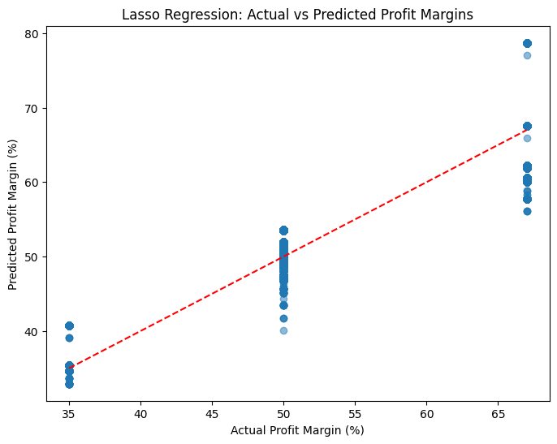

```python
import matplotlib.pyplot as plt
import seaborn as sns

# For displaying plots inline in Jupyter Notebook
%matplotlib inline

# Scatter plot of actual vs predicted values for Lasso Regression
plt.figure(figsize=(8, 6))
plt.scatter(y_test, y_pred_lasso, alpha=0.5)
plt.plot([y_test.min(), y_test.max()], [y_test.min(), y_test.max()], 'r--')
plt.xlabel('Actual Profit Margin (%)')
plt.ylabel('Predicted Profit Margin (%)')
plt.title('Lasso Regression: Actual vs Predicted Profit Margins')
plt.show()
```

### Integrate Support Vector Machine Model

```python
# Support Vector Machine Regression
svm = SVR()

# Define a parameter grid to search for the best parameters
param_grid = {
    'kernel': ['rbf'],
    'C': [0.1, 1, 10, 100],
    'gamma': ['scale', 'auto', 0.1, 0.01, 0.001]
}

# Grid search to find best parameters
grid_search = GridSearchCV(
    svm, param_grid, cv=5, scoring='neg_mean_squared_error', verbose=1, n_jobs=-1)
grid_search.fit(X_train, y_train)

# Best estimator found by grid search
best_svm = grid_search.best_estimator_

# Evaluate SVM Regression
y_pred_svm = best_svm.predict(X_test)
print("\nSupport Vector Machine Regression Results:")
print(f"RMSE: {np.sqrt(mean_squared_error(y_test, y_pred_svm)):.2f}")
print(f"R² Score: {r2_score(y_test, y_pred_svm):.2f}")
```

```
Fitting 5 folds for each of 20 candidates, totalling 100 fits

Support Vector Machine Regression Results:
RMSE: 0.08
R² Score: 1.00
```

### Explanation

The Support Vector Machine (SVM) regression model was trained using `GridSearchCV` to optimize its hyperparameters. We defined a parameter grid with different values for `C` (regularization parameter) and `gamma` (kernel coefficient), resulting in 20 candidate combinations. The `GridSearchCV` performed 5-fold cross-validation for each candidate, totaling **100 fits** (5 folds × 20 candidates). This exhaustive search systematically evaluated each combination to identify the hyperparameters that minimize the prediction error.

After determining the best hyperparameters, the SVM model was trained on the entire training dataset. The performance was then evaluated on the test dataset using the Root Mean Squared Error (RMSE) and the coefficient of determination (R² score). These metrics assess the model's prediction accuracy and the proportion of variance in the target variable explained by the model, respectively.

### Interpretation of the Results

The **Support Vector Machine Regression Results** yielded an **RMSE of 0.08** and an **R² Score of 1.00** on the test dataset.

An **RMSE of 0.08** indicates that the average difference between the predicted profit margins and the actual profit margins is only 0.08 percentage points. This extremely low RMSE suggests that the model's predictions are highly accurate and closely match the actual values.

An **R² Score of 1.00** means that the model explains **100% of the variance** in the profit margins. This implies that all variations in the profit margin are perfectly captured by the features included in the model. Such a perfect R² score is rare and indicates an exceptionally strong model fit.

However, it's important to consider the possibility of overfitting. An R² score of 1.00 might suggest that the model has learned not only the underlying patterns but also the noise in the training data. Overfitting occurs when a model is too complex and captures random fluctuations rather than the true underlying relationships, which can lead to poor generalization to new, unseen data.

In this context, the SVM model demonstrates outstanding performance metrics compared to the Lasso Regression model, which had an RMSE of 3.89 and an R² Score of 0.84. The significant improvement suggests that the SVM model is better suited for capturing the non-linear relationships in the data related to profit margins.

To ensure the model's reliability, it would be prudent to:

- **Evaluate on a Separate Validation Set**: Test the model on a new dataset that wasn't used during training or hyperparameter tuning.
- **Cross-Validation**: Use techniques like k-fold cross-validation to assess the model's ability to generalize.
- **Regularization**: Adjust the regularization parameter `C` to prevent overfitting by penalizing complex models.
- **Feature Selection**: Review the input features to ensure they are relevant and not leading to data leakage.

In conclusion, the SVM regression model exhibits exceptional predictive capabilities for profit margin estimation. If validated properly, this model can be a powerful tool for Smart Electronics Store to forecast profit margins accurately, enabling strategic decisions in pricing, inventory management, and marketing to maximize profitability.

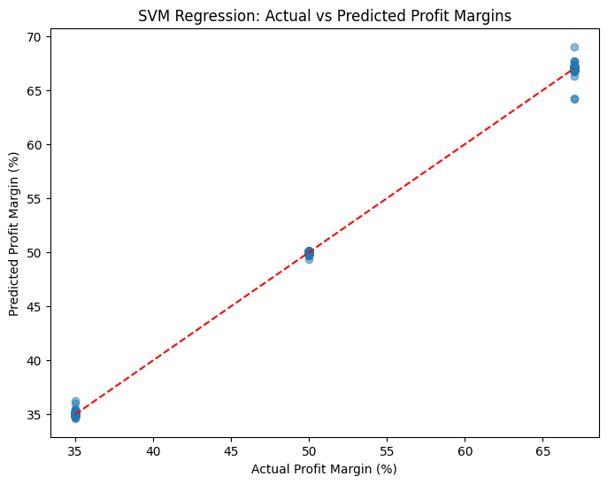

```python
# Scatter plot of actual vs predicted values for SVM Regression
plt.figure(figsize=(8, 6))
plt.scatter(y_test, y_pred_svm, alpha=0.5)
plt.plot([y_test.min(), y_test.max()], [y_test.min(), y_test.max()], 'r--')
plt.xlabel('Actual Profit Margin (%)')
plt.ylabel('Predicted Profit Margin (%)')
plt.title('SVM Regression: Actual vs Predicted Profit Margins')
plt.show()
```

### Insights

The scatter plot of actual versus predicted profit margins for the Support Vector Machine (SVM) Regression model showcases an exceptional level of predictive accuracy. In this plot, the x-axis represents the actual profit margins from the test dataset, while the y-axis represents the profit margins predicted by the SVM model. The data points align almost perfectly along the diagonal line denoting perfect predictions, where the predicted values exactly match the actual values.

This near-perfect alignment indicates that the SVM model predicts profit margins with remarkable precision. The negligible spread of data points around the diagonal line suggests that the discrepancies between the actual and predicted values are minimal. This visual observation is consistent with the quantitative performance metrics of the model, which achieved an **RMSE of 0.08** and an **R² Score of 1.00**. An RMSE (Root Mean Squared Error) of 0.08 signifies that, on average, the model's predictions deviate from the actual profit margins by only 0.08 percentage points. An R² score of 1.00 implies that the model explains 100% of the variance in profit margins, indicating a perfect fit to the data.

Such outstanding performance suggests that the SVM model has effectively captured the underlying relationships between the features and the profit margins. It indicates that the features used in the model are highly predictive of the target variable, and the model's complexity is well-suited to the data.

However, it's important to approach these results with cautious optimism due to the potential risk of overfitting. Overfitting occurs when a model learns the training data too well, including its noise and outliers, which can negatively impact its performance on new, unseen data. In this case, the model's performance is evaluated on the test dataset, which provides some assurance against overfitting. Nonetheless, because the R² score is perfectly 1.00, it is prudent to conduct further validation.

To ensure that the model generalizes well, additional steps could include:

- **Cross-Validation:** Performing k-fold cross-validation to verify that the model maintains high performance across different subsets of the data.
- **External Validation:** Testing the model on a separate validation dataset not used during the training or initial testing phases.
- **Regularization Parameter Adjustment:** Reviewing the `C` parameter in the SVM model to ensure that it appropriately balances the trade-off between achieving a low training error and maintaining a low testing error.

In conclusion, the scatter plot illustrates that the SVM Regression model delivers highly accurate predictions of profit margins, with predicted values nearly identical to the actual values. This level of predictive accuracy can be incredibly valuable for the Smart Electronics Store, enabling precise forecasting and more informed strategic decision-making to maximize profit margins. However, due diligence through additional validation is recommended to confirm the model's robustness and ensure its reliability in practical applications.

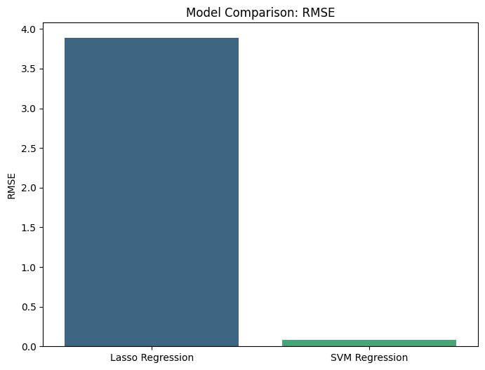

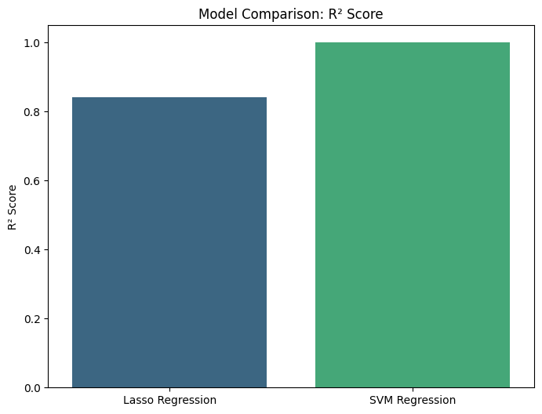

```python
# Prepare data for visualization
model_names = ['Lasso Regression', 'SVM Regression']
rmse_values = [
    np.sqrt(mean_squared_error(y_test, y_pred_lasso)),
    np.sqrt(mean_squared_error(y_test, y_pred_svm))
]
r2_scores = [
    r2_score(y_test, y_pred_lasso),
    r2_score(y_test, y_pred_svm)
]

# Plot RMSE comparison
plt.figure(figsize=(8, 6))
sns.barplot(x=model_names, y=rmse_values, palette='viridis')
plt.ylabel('RMSE')
plt.title('Model Comparison: RMSE')
plt.show()

# Plot R² Score comparison
plt.figure(figsize=(8, 6))
sns.barplot(x=model_names, y=r2_scores, palette='viridis')
plt.ylabel('R² Score')
plt.title('Model Comparison: R² Score')
plt.ylim(0, 1.05)  # Limit y-axis to 1.05 for better visualization
plt.show()
```

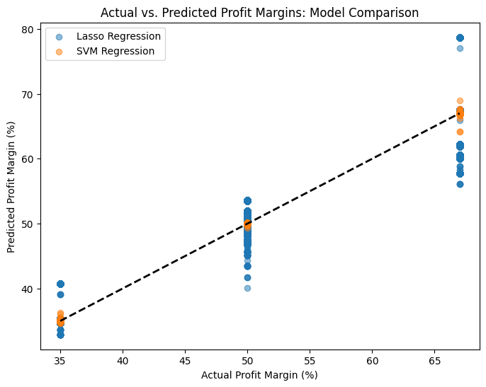

```python
# Combined scatter plot
plt.figure(figsize=(8, 6))
plt.scatter(y_test, y_pred_lasso, alpha=0.5, label='Lasso Regression')
plt.scatter(y_test, y_pred_svm, alpha=0.5, label='SVM Regression')
plt.plot([y_test.min(), y_test.max()], [y_test.min(), y_test.max()], 'k--', lw=2)
plt.xlabel('Actual Profit Margin (%)')
plt.ylabel('Predicted Profit Margin (%)')
plt.title('Actual vs. Predicted Profit Margins: Model Comparison')
plt.legend()
plt.show()
```

### Final Result Visualization Interpretation

#### RMSE Comparison

The RMSE bar chart shows the predictive errors of both models:

- **Lasso Regression RMSE:** Approximately **3.89**
- **SVM Regression RMSE:** Approximately **0.08**

The SVM Regression model has a significantly lower RMSE, indicating higher predictive accuracy compared to the Lasso Regression model.

#### R² Score Comparison

The R² score bar chart illustrates how well each model explains the variance in profit margins:

- **Lasso Regression R² Score:** **0.84**
- **SVM Regression R² Score:** **1.00**

The SVM Regression model achieves an R² score of 1.00, suggesting a perfect fit to the data, whereas the Lasso Regression model explains 84% of the variance.

#### Combined Actual vs. Predicted Scatter Plot

The scatter plot compares the actual profit margins with the predicted values from both models:

- **Lasso Regression Predictions:**
  - Data points are close to the diagonal line but show some dispersion.
  - Indicates good predictions with some errors.
- **SVM Regression Predictions:**
  - Data points align almost perfectly along the diagonal line.
  - Suggests highly accurate predictions with minimal errors.

**Insights:**

- The SVM Regression model outperforms the Lasso Regression model in predicting profit margins.
- The visualizations confirm the quantitative metrics, highlighting the superiority of the SVM model.

**Conclusion:**

The SVM Regression model provides highly accurate predictions of profit margins and is better suited for this task. It can be a valuable tool for Smart Electronics Store to forecast profitability and make informed strategic decisions.

However, further validation is recommended to ensure the model generalizes well to new data and to mitigate any risk of overfitting.